# 市场观察

2017/08/16

## A、指数估值

### (a1)动态市盈率、市净率

核心指数成分股近18个月的动态市盈率及动态市净率中位数走势如下图所示：

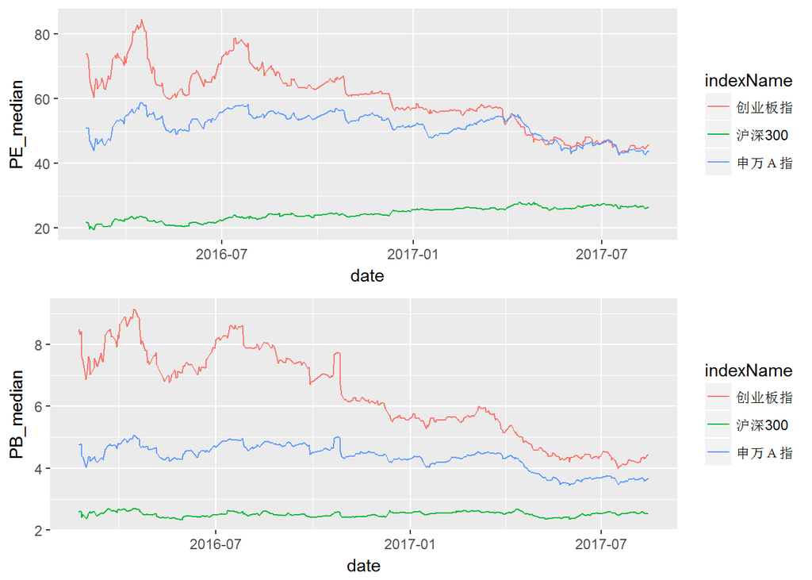

### (a2)动态市盈率、市净率百分位

核心指数近18个月的动态市盈率百分位及动态市净率百分位走势如下图所示：

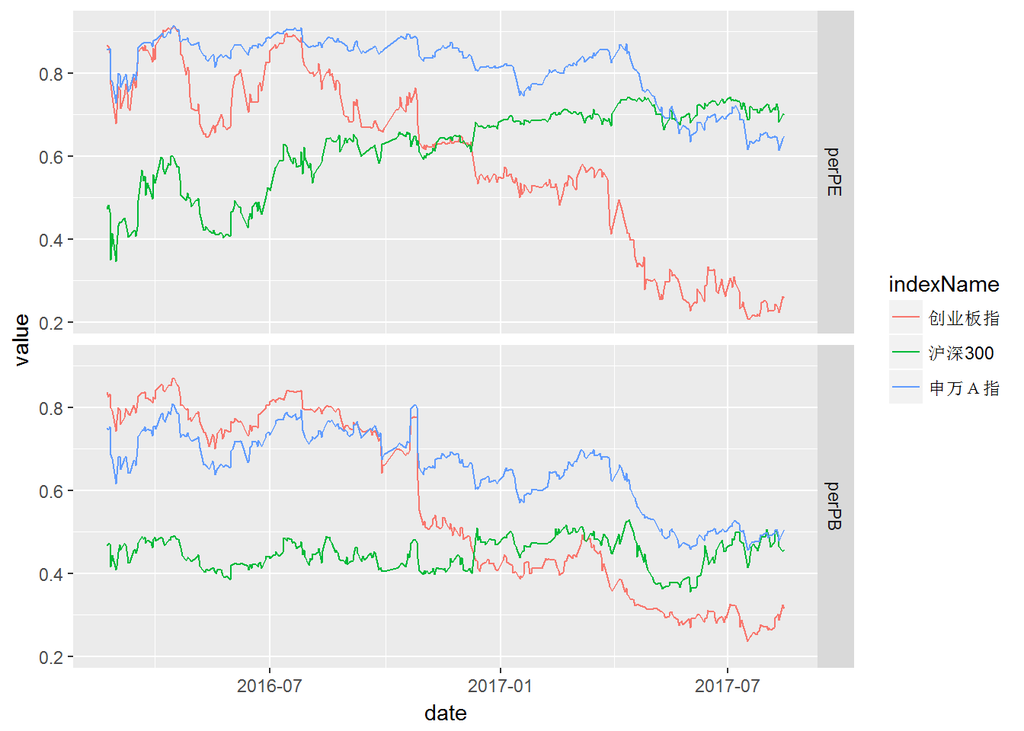

### (a3)指数估值概览

纳入观察的指数最新的估值情况如下表，根据市盈率和市净率分位数均值降序排列。

| 指数代码 | 指数简称 | 日期 | 动态市盈率 | 市盈率百分位 | 动态市净率 | 市净率百分位 |
| --- | --- | --- | --- | --- | --- | --- |
| EI000819 | 有色金属 | 2017-08-15 | 62.4 | 83% | 3.6 | 66% |
| EI000979 | 大宗商品 | 2017-08-15 | 40.8 | 76% | 2.7 | 56% |
| EI000300 | 沪深300 | 2017-08-15 | 26.4 | 70% | 2.5 | 46% |
| EI801003 | 申万Ａ指 | 2017-08-15 | 44.0 | 65% | 3.7 | 51% |
| EI399330 | 深证100 | 2017-08-15 | 31.6 | 64% | 3.5 | 46% |
| EI399959 | 军工指数 | 2017-08-15 | 81.4 | 55% | 3.9 | 48% |
| EI399005 | 中小板指P | 2017-08-15 | 38.5 | 54% | 4.5 | 40% |
| EI000932 | 中证消费 | 2017-08-15 | 31.5 | 47% | 4.1 | 43% |
| EI000905 | 中证500 | 2017-08-15 | 35.9 | 48% | 2.9 | 33% |
| EI000934 | 中证金融 | 2017-08-15 | 18.9 | 61% | 1.8 | 17% |
| EI000998 | 中证TMT | 2017-08-15 | 42.1 | 43% | 3.7 | 32% |
| EI000922 | 中证红利 | 2017-08-15 | 16.4 | 41% | 1.7 | 24% |
| EI000016 | 上证50 | 2017-08-15 | 16.5 | 49% | 1.6 | 12% |
| EI399006 | 创业板指 | 2017-08-15 | 45.6 | 26% | 4.4 | 31% |
| EI000827 | 中证环保 | 2017-08-15 | 34.9 | 26% | 3.1 | 30% |
| EI000933 | 中证医药 | 2017-08-15 | 33.4 | 26% | 3.6 | 3% |

### (a4)另类估值

我国10年期国债收益率、金银比价、金油比价，2000年以来的历史百分位如下图所示：

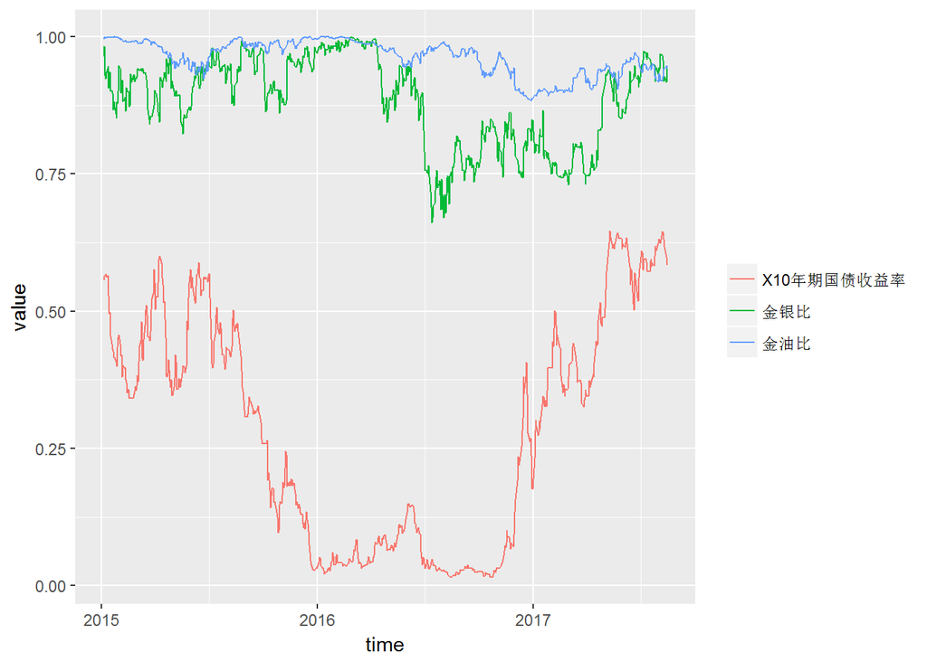

## B、基差及市场情绪

### (b1)基差走势

三大股指期货合约基差走势如下图，其中当月合约和次月合约年化基差百分比波动较大，仅展示合约基差百分比，当季合约和次季合约展示基差年化百分比：

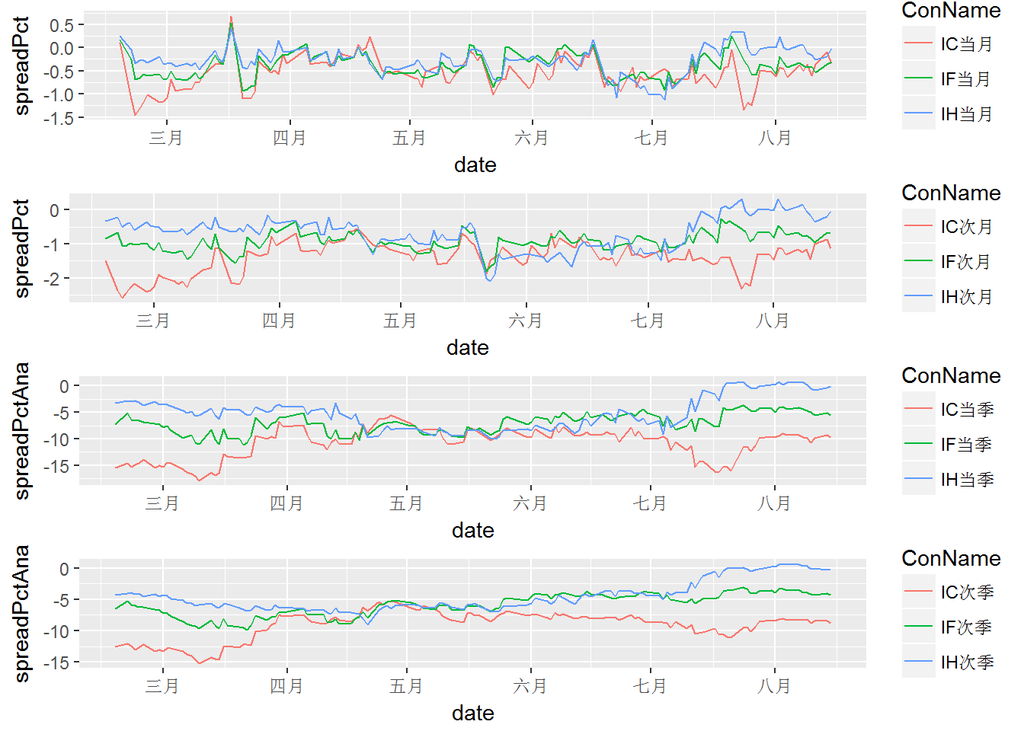

### (b2)基差概况

三大股指期货连续合约基差概况如下表，近月合约临近到期日，年化基差百分比数据波动较大：

| 日期 | 合约代码 | 合约收盘价 | 指数收盘价 | 基差 | 基差百分比 | 年化基差百分比 |
| --- | --- | --- | --- | --- | --- | --- |
| 2017-08-15 | IC1708 | 6292.8 | 6314.8 | -22.0 | -0.3% | -52.6% |
| 2017-08-15 | IC1709 | 6243.2 | 6314.8 | -71.6 | -1.1% | -14.2% |
| 2017-08-15 | IC1712 | 6116.4 | 6314.8 | -198.4 | -3.1% | -9.7% |
| 2017-08-15 | IC1803 | 5997.0 | 6314.8 | -317.8 | -5.0% | -8.8% |
| 2017-08-15 | IF1708 | 3694.4 | 3706.1 | -11.7 | -0.3% | -46.5% |
| 2017-08-15 | IF1709 | 3680.6 | 3706.1 | -25.5 | -0.7% | -8.4% |
| 2017-08-15 | IF1712 | 3639.2 | 3706.1 | -66.9 | -1.8% | -5.5% |
| 2017-08-15 | IF1803 | 3614.4 | 3706.1 | -91.7 | -2.5% | -4.3% |
| 2017-08-15 | IH1708 | 2605.0 | 2605.2 | -0.2 | -0.0% | -1.1% |
| 2017-08-15 | IH1709 | 2604.2 | 2605.2 | -1.0 | -0.0% | -0.5% |
| 2017-08-15 | IH1712 | 2604.4 | 2605.2 | -0.8 | -0.0% | -0.1% |
| 2017-08-15 | IH1803 | 2601.6 | 2605.2 | -3.6 | -0.1% | -0.2% |

### (b3)市场情绪(provided by han.qian)

市场情绪记录近60天每天自然涨跌停(剔除一字板)、创60日新高新低、多头排列空头排列(均线组合5,30,60,120)的股票数。

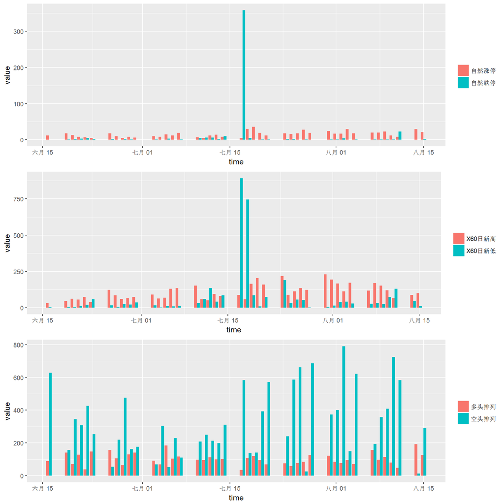

## C、套利和事件

### (c1)复牌股票套利

近两天复牌股票套利情况如下表：

[1] “No Arbitrage!”

### (c2)解禁

解禁分成两个部分，定增解禁和IPO解禁，涨跌幅记录是过去十个交易日的股票涨跌幅和对应行业指数涨跌幅。伴随着去年下半年IPO逐步正常化，今后IPO解禁给市场造成的抛压会持续存在，所以纳入观察。近期定增解禁的股票情况如下表。

| 股票代码 | 股票简称 | 解禁日 | 解禁数量 | 解禁百分比 | 区间涨跌幅 | 所属行业指数 | 行业指数涨跌幅 |
| --- | --- | --- | --- | --- | --- | --- | --- |
| EQ601137 | 博威合金 | 2017-08-18 | 1.34 | 31% | 0.3% | 申万有色金属 | 1.9% |
| EQ600075 | 新疆天业 | 2017-08-21 | 2.18 | 36% | -7.2% | 申万化工 | -1.8% |
| EQ002743 | 富煌钢构 | 2017-08-21 | 0.89 | 78% | 40.9% | 申万建筑装饰 | -2.2% |
| EQ002199 | 东晶电子 | 2017-08-21 | 0.54 | 41% | 3.0% | 申万电子 | 1.6% |
| EQ600175 | 美都能源 | 2017-08-21 | 10.03 | 69% | -3.2% | 申万综合 | 0.9% |
| EQ002772 | 众兴菌业 | 2017-08-22 | 0.54 | 33% | 1.1% | 申万农林牧渔 | 1.0% |
| EQ002371 | 北方华创 | 2017-08-22 | 1.85 | 111% | 0.4% | 申万电子 | 1.6% |
| EQ000719 | 大地传媒 | 2017-08-22 | 3.56 | 53% | -1.7% | 申万传媒 | 1.1% |
| EQ600661 | 新南洋 | 2017-08-22 | 0.78 | 43% | -2.1% | 申万传媒 | 1.1% |
| EQ002537 | 海联金汇 | 2017-08-23 | 1.96 | 30% | 19.2% | 申万机械设备 | -0.1% |
| EQ002583 | 海能达 | 2017-08-23 | 1.90 | 22% | -2.6% | 申万通信 | -0.0% |
| EQ300230 | 永利股份 | 2017-08-23 | 0.85 | 47% | -0.8% | 申万化工 | -1.8% |
| EQ002589 | 瑞康医药 | 2017-08-24 | 2.06 | 30% | -2.9% | 申万医药生物 | 1.6% |
| EQ600331 | 宏达股份 | 2017-08-28 | 10.00 | 97% | -3.1% | 申万有色金属 | 1.9% |
| EQ000413 | 东旭光电 | 2017-08-28 | 11.05 | 37% | -2.7% | 申万电子 | 1.6% |
| EQ002733 | 雄韬股份 | 2017-08-28 | 0.44 | 38% | -3.4% | 申万电气设备 | 0.1% |
| EQ600604 | 市北高新 | 2017-08-29 | 2.79 | 37% | 7.0% | 申万房地产 | -3.1% |
| EQ300373 | 扬杰科技 | 2017-08-30 | 0.50 | 28% | 3.2% | 申万电子 | 1.6% |
| EQ603017 | 中衡设计 | 2017-08-30 | 0.32 | 26% | 1.9% | 申万建筑装饰 | -2.2% |

近期IPO解禁的股票情况如下表。

| 股票代码 | 股票简称 | 解禁日 | 解禁数量 | 解禁百分比 | 区间涨跌幅 | 所属行业指数 | 行业指数涨跌幅 | 上市日 |
| --- | --- | --- | --- | --- | --- | --- | --- | --- |
| EQ300348 | 长亮科技 | 2017-08-17 | 0.44 | 27% | 0.6% | 申万计算机 | 3.4% | 2012-08-17 |
| EQ300532 | 今天国际 | 2017-08-18 | 0.28 | 74% | 26.1% | 申万计算机 | 3.4% | 2016-08-18 |
| EQ300533 | 冰川网络 | 2017-08-18 | 0.31 | 125% | -0.5% | 申万传媒 | 1.1% | 2016-08-18 |
| EQ603986 | 兆易创新 | 2017-08-18 | 0.97 | 195% | -8.8% | 申万电子 | 1.6% | 2016-08-18 |
| EQ603515 | 欧普照明 | 2017-08-21 | 0.40 | 69% | -1.5% | 申万电子 | 1.6% | 2016-08-19 |
| EQ603099 | 长白山 | 2017-08-22 | 1.64 | 160% | -3.1% | 申万休闲服务 | -1.6% | 2014-08-22 |
| EQ603031 | 安德利 | 2017-08-22 | 0.20 | 100% | -3.6% | 申万食品饮料 | 3.7% | 2016-08-22 |
| EQ300540 | 深冷股份 | 2017-08-23 | 0.30 | 150% | -1.7% | 申万机械设备 | -0.1% | 2016-08-23 |
| EQ002809 | 红墙股份 | 2017-08-23 | 0.33 | 109% | -11.8% | 申万化工 | -1.8% | 2016-08-23 |
| EQ601579 | 会稽山 | 2017-08-25 | 1.52 | 61% | 4.0% | 申万食品饮料 | 3.7% | 2014-08-25 |
| EQ300538 | 同益股份 | 2017-08-28 | 0.03 | 25% | 4.6% | 申万交通运输 | -0.5% | 2016-08-26 |
| EQ002810 | 山东赫达 | 2017-08-28 | 0.27 | 113% | -1.5% | 申万化工 | -1.8% | 2016-08-26 |
| EQ603007 | 花王股份 | 2017-08-28 | 1.11 | 133% | 3.1% | 申万建筑装饰 | -2.2% | 2016-08-26 |
| EQ300539 | 横河模具 | 2017-08-30 | 0.12 | 23% | 7.4% | 申万化工 | -1.8% | 2016-08-30 |

### (c3)中小板业绩预增预测(provided by han.qian)

中小板规定正式财务报告发布的同时需要发布新一期的业绩预报，比如年报中会包含一季报预告的情况。我们假设公司的盈利状况有动量效应，年报预增的公司一季度也会预增，在正式财务报告发布前20个交易日开始埋伏，然后等正式报告发布日卖出。具体研究参见钱瀚前期的研究。需要注意的是这里的收益率仅做展示，仅仅是每日全部入选股票的平均收益率，并没有做成一个事件组合。

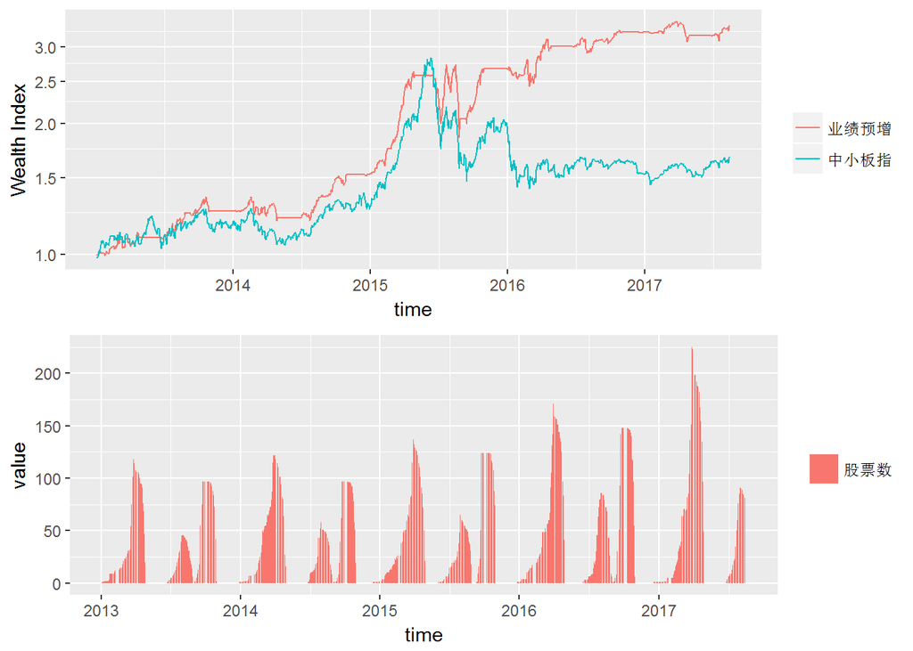

历年收益统计如下表所示。

|  | 业绩预增 | 中小板指 |
| --- | --- | --- |
| 2013-01-04 ~ 2013-12-31 | 26.0% | 17.5% |
| 2014-01-02 ~ 2014-12-31 | 21.7% | 9.7% |
| 2015-01-05 ~ 2015-12-31 | 74.4% | 53.7% |
| 2016-01-04 ~ 2016-12-30 | 21.5% | -22.9% |
| 2017-01-03 ~ 2017-08-15 | 3.6% | 10.2% |
| Cumulative Return | 236.4% | 68.3% |
| Annualized Return | 30.0% | 11.9% |

### (c4)ST摘帽(provided by han.qian)

具体策略可以参见吴先兴的潜伏ST摘帽报告。

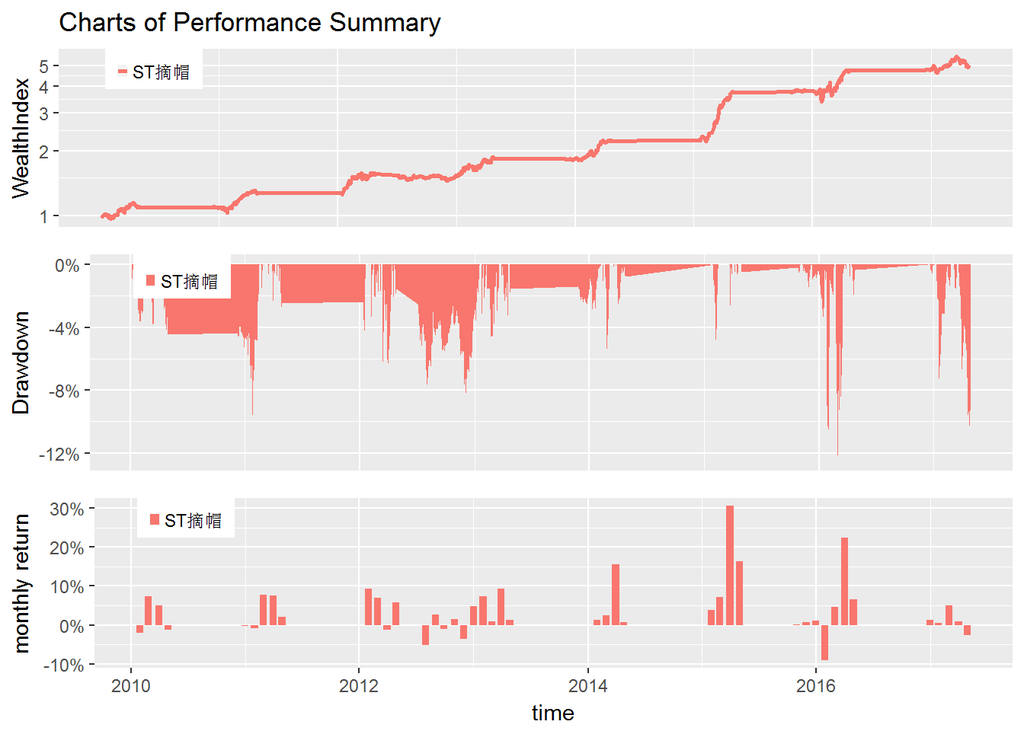

最新持仓如下表所示。

| date | stockID | stockName | wgt |
| --- | --- | --- | --- |
| 2017-04-28 | EQ000505 | 珠江控股 | 0.1 |
| 2017-04-28 | EQ000511 | *ST 烯碳 | 0.1 |
| 2017-04-28 | EQ600339 | 中油工程 | 0.1 |

### (c5)主动量化及指数增强

主动量化基金最近一年和最近一个季度的收益率密度图如下所示。

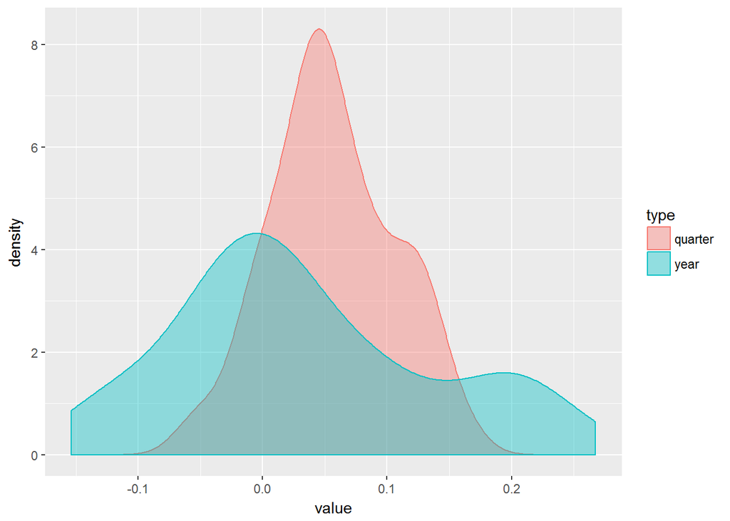

主动量化基金近一年和近一个季度表现最好的20只基金如下表所示。

| 季度排名 | 基金简称 | 成立日 | 总规模 | 季度收益 | 年度排名 | 基金简称 | 成立日 | 总规模 | 年度收益 |
| --- | --- | --- | --- | --- | --- | --- | --- | --- | --- |
| 1 | 德邦量化优选A | 2017-03-24 | 0.1 | 14.1% | 1 | 景顺长城量化新动力 | 2016-07-13 | 4.0 | 26.8% |
| 2 | 华泰柏瑞量化优选 | 2014-12-17 | 9.1 | 13.8% | 2 | 华泰柏瑞量化优选 | 2014-12-17 | 9.1 | 23.7% |
| 3 | 景顺长城量化新动力 | 2016-07-13 | 4.0 | 13.3% | 3 | 华泰柏瑞量化智慧 | 2015-06-03 | 5.6 | 20.0% |
| 4 | 中融量化智选A | 2017-03-22 | 2.5 | 13.3% | 4 | 华泰柏瑞量化驱动 | 2015-03-24 | 21.8 | 19.9% |
| 5 | 华泰柏瑞量化驱动 | 2015-03-24 | 21.8 | 13.1% | 5 | 华泰柏瑞量化A | 2013-08-02 | 44.3 | 19.3% |
| 6 | 华泰柏瑞量化A | 2013-08-02 | 44.3 | 13.1% | 6 | 华泰柏瑞量化先行 | 2010-06-22 | 7.8 | 19.0% |
| 7 | 华泰柏瑞量化智慧 | 2015-06-03 | 5.6 | 12.0% | 7 | 九泰久盛量化先锋A | 2015-11-10 | 4.3 | 17.6% |
| 8 | 永赢量化灵活配置 | 2015-09-01 | 0.7 | 12.0% | 8 | 泰达宏利同顺大数据A | 2016-02-23 | 1.8 | 11.4% |
| 9 | 华泰柏瑞量化先行 | 2010-06-22 | 7.8 | 11.9% | 9 | 景顺长城量化精选 | 2015-02-04 | 14.0 | 11.0% |
| 10 | 九泰久盛量化先锋A | 2015-11-10 | 4.3 | 11.1% | 10 | 大成核心双动力 | 2010-06-22 | 1.3 | 9.5% |
| 11 | 嘉实腾讯自选股大数据 | 2015-12-07 | 5.5 | 10.1% | 11 | 永赢量化灵活配置 | 2015-09-01 | 0.7 | 8.0% |
| 12 | 景顺长城量化精选 | 2015-02-04 | 14.0 | 10.0% | 12 | 东吴安鑫量化 | 2016-06-03 | 2.4 | 6.3% |
| 13 | 大成核心双动力 | 2010-06-22 | 1.3 | 9.1% | 13 | 华商大盘量化精选 | 2013-04-09 | 11.6 | 3.9% |
| 14 | 中融量化小盘A | 2017-05-17 | NA | 8.5% | 14 | 嘉实腾讯自选股大数据 | 2015-12-07 | 5.5 | 3.7% |
| 15 | 光大事件驱动 | 2017-01-18 | 5.7 | 8.3% | 15 | 泰达宏利改革动力A | 2015-02-13 | 16.6 | 3.7% |
| 16 | 泰达宏利量化 | 2016-08-30 | 2.4 | 8.0% | 16 | 建信多因子量化 | 2016-08-09 | 1.7 | 2.8% |
| 17 | 大成动态量化 | 2016-09-20 | 2.5 | 7.6% | 17 | 长信量化多策略A | 2015-07-14 | 3.2 | 2.6% |
| 18 | 建信多因子量化 | 2016-08-09 | 1.7 | 7.3% | 18 | 民生加银量化中国 | 2016-05-19 | 1.7 | 2.2% |
| 19 | 大摩睿成大盘弹性 | 2017-04-12 | 1.8 | 7.3% | 19 | 申万菱信量化小盘 | 2011-06-16 | 29.1 | 1.9% |
| 20 | 泰达宏利同顺大数据A | 2016-02-23 | 1.8 | 7.2% | 20 | 南方策略优化 | 2010-03-30 | 12.3 | 1.4% |

指数增强基金表现如下所示。

| 基金代码 | 基金简称 | 成立日 | 总规模 | 季度超额收益 | 年度超额收益 |
| --- | --- | --- | --- | --- | --- |
| 000312.OF | 华安沪深300量化A | 2013-09-27 | 1.7 | 7.8% | 12.7% |
| 110030.OF | 易方达沪深300量化 | 2013-06-07 | 9.2 | 5.8% | 11.7% |
| 003876.OF | 华宝兴业沪深300 | 2016-12-09 | 3.5 | 4.1% | NA% |
| 100038.OF | 富国沪深300 | 2009-12-16 | 20.9 | 3.8% | 6.0% |
| 000311.OF | 景顺长城沪深300 | 2013-10-29 | 27.0 | 3.7% | 13.6% |
| 004190.OF | 招商沪深300A | 2017-02-10 | 2.2 | 2.4% | NA% |
| 003261.OF | 安信沪深300A | 2016-10-12 | 1.5 | 2.2% | NA% |
| 519116.OF | 浦银安盛沪深300 | 2010-12-10 | 1.3 | 0.9% | 6.3% |
| 003015.OF | 中金沪深300A | 2016-07-22 | 0.1 | 0.8% | -1.2% |
| 002310.OF | 创金合信沪深300A | 2015-12-31 | 2.3 | 0.1% | 1.9% |
| 004194.OF | 招商中证1000A | 2017-03-03 | 1.4 | 4.6% | NA% |
| 003646.OF | 创金合信中证1000A | 2016-12-22 | 1.9 | 3.9% | NA% |
| 003986.OF | 申万菱信中证500优选 | 2017-01-10 | 3.5 | 11.1% | NA% |
| 004192.OF | 招商中证500A | 2017-05-17 | NA | 7.3% | NA% |
| 002906.OF | 南方中证500增强A | 2016-11-23 | 1.9 | 4.5% | NA% |
| 003016.OF | 中金中证500A | 2016-07-22 | 0.1 | 2.9% | 4.2% |
| 002311.OF | 创金合信中证500A | 2015-12-31 | 1.7 | 1.7% | 7.0% |
| 000478.OF | 建信中证500 | 2014-01-27 | 12.8 | 1.6% | 8.4% |
| 002510.OF | 申万菱信中证500 | 2016-04-21 | 2.4 | -2.6% | -2.9% |

## D、择时

### (d1)等权指数

从历史来看，A股市场存在小盘股效应，市值小的股票长期整体跑赢大市值的股票，美股市场同样存在类似的现象。而目前大部分指数的编制方案都是类似市值加权，为了抛去市值的影响，下面展示几个等权指数，其中中证500等权和沪深300等权是现有的指数，中证全指等权是自己编制的指数。等权指数可以视为一个更好地业绩比较基准。等权指数走势如下图：

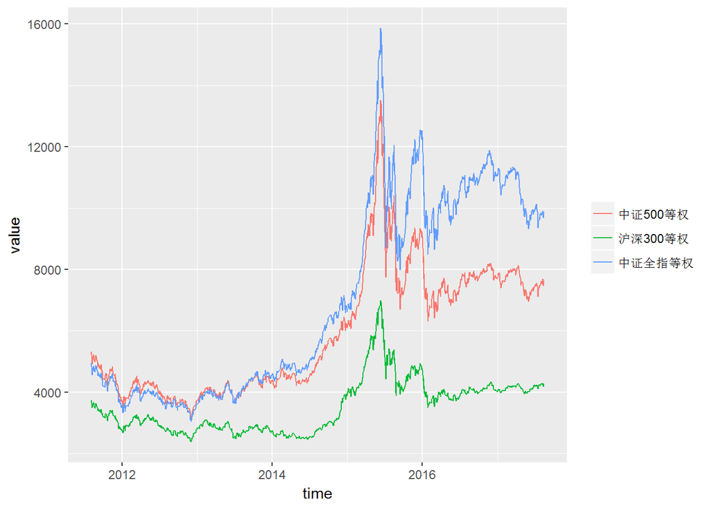

等权指数收益率统计见下表：

|  | 中证500等权 | 沪深300等权 | 中证全指等权 |
| --- | --- | --- | --- |
| 2011-08-02 ~ 2011-12-30 | -29.2% | -25.5% | -27.8% |
| 2012-01-04 ~ 2012-12-31 | -0.0% | 1.5% | 2.2% |
| 2013-01-04 ~ 2013-12-31 | 16.7% | -3.2% | 25.8% |
| 2014-01-02 ~ 2014-12-31 | 40.2% | 43.7% | 46.0% |
| 2015-01-05 ~ 2015-12-31 | 47.6% | 20.1% | 84.4% |
| 2016-01-04 ~ 2016-12-30 | -15.1% | -15.1% | -10.3% |
| 2017-01-03 ~ 2017-08-15 | -0.9% | 5.8% | -10.5% |
| 累计收益率 | 43.8% | 13.6% | 100.7% |
| 年化收益率 | 6.2% | 2.1% | 12.2% |
| 年化波动率 | 28.2% | 25.4% | 28.6% |
| 年化Sharpe值 | 22.0% | 8.4% | 42.8% |
| 最大回撤 | 53.3% | 50.0% | 49.7% |

### (d2)大盘均线强弱指数

大盘均线强弱指数在一定程度上可以视为一个反转指标，当大盘均线得分接近8分时，预示市场接近顶部，当大盘均线得分接近0分时，预示市场接近底部。  
大盘均线强弱指数近一年来走势如下图：

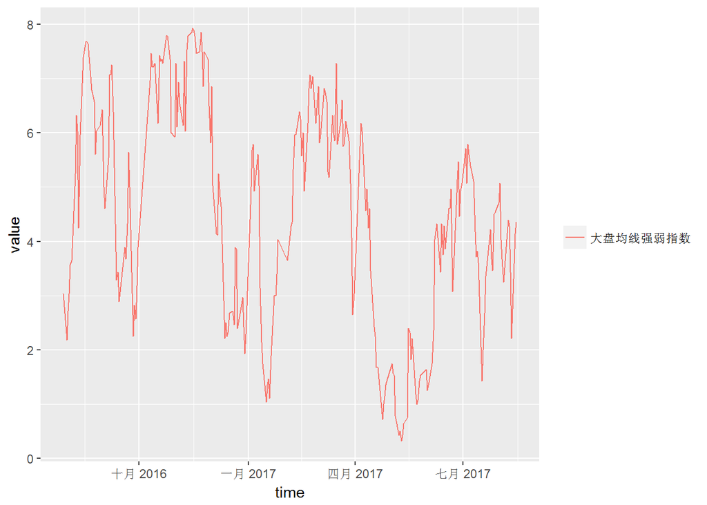

申万一级行业的最新得分见下表：

| 日期 | 指数代码 | 行业 | 最新得分 | 上周得分 |
| --- | --- | --- | --- | --- |
| 2017-08-15 | EI801080 | 电子 | 8 | 0 |
| 2017-08-15 | EI801120 | 食品饮料 | 8 | 8 |
| 2017-08-15 | EI801710 | 建筑材料 | 8 | 8 |
| 2017-08-15 | EI801040 | 钢铁 | 6 | 8 |
| 2017-08-15 | EI801050 | 有色金属 | 6 | 8 |
| 2017-08-15 | EI801170 | 交通运输 | 6 | 7 |
| 2017-08-15 | EI801230 | 综合 | 6 | 6 |
| 2017-08-15 | EI801750 | 计算机 | 6 | 3 |
| 2017-08-15 | EI801020 | 采掘 | 5 | 8 |
| 2017-08-15 | EI801030 | 化工 | 5 | 7 |
| 2017-08-15 | EI801140 | 轻工制造 | 5 | 5 |
| 2017-08-15 | EI801150 | 医药生物 | 5 | 4 |
| 2017-08-15 | EI801730 | 电气设备 | 5 | 4 |
| 2017-08-15 | EI801740 | 国防军工 | 5 | 5 |
| 2017-08-15 | EI801010 | 农林牧渔 | 4 | 5 |
| 2017-08-15 | EI801110 | 家用电器 | 4 | 4 |
| 2017-08-15 | EI801200 | 商业贸易 | 4 | 3 |
| 2017-08-15 | EI801760 | 传媒 | 4 | 3 |
| 2017-08-15 | EI801780 | 银行 | 4 | 5 |
| 2017-08-15 | EI801790 | 非银金融 | 4 | 5 |
| 2017-08-15 | EI801890 | 机械设备 | 4 | 5 |
| 2017-08-15 | EI801160 | 公用事业 | 3 | 3 |
| 2017-08-15 | EI801720 | 建筑装饰 | 3 | 0 |
| 2017-08-15 | EI801770 | 通信 | 3 | 3 |
| 2017-08-15 | EI801210 | 休闲服务 | 1 | 0 |
| 2017-08-15 | EI801130 | 纺织服装 | 0 | 3 |
| 2017-08-15 | EI801180 | 房地产 | 0 | 0 |
| 2017-08-15 | EI801880 | 汽车 | 0 | 0 |

### (d3)LLT及均线择时

LLT本质上是一个改进的单均线择时指标，较原始的均线择时延迟更低。  
择时模型和指数本身的净值走势如下图：

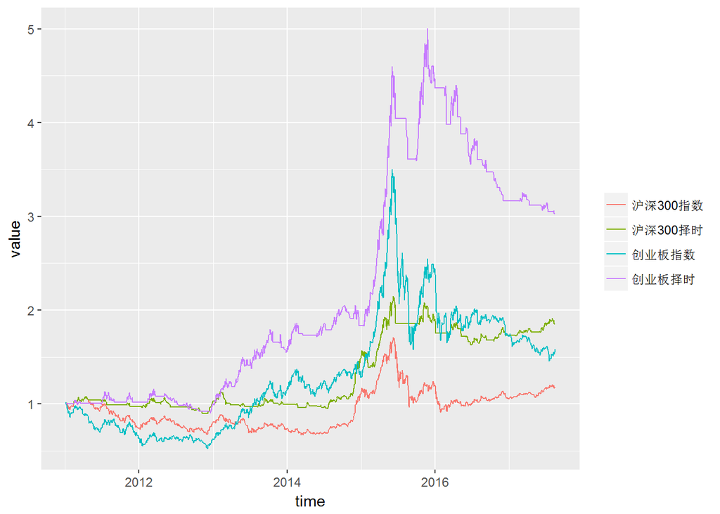

择时模型和指数的收益率统计如下表：

|  | 沪深300指 | 沪深300LLT | 创业板指 | 创业板MA |
| --- | --- | --- | --- | --- |
| 2011-01-04 ~ 2011-12-30 | -25.0% | -2.5% | -35.9% | 1.9% |
| 2012-01-04 ~ 2012-12-31 | 7.6% | 5.4% | -2.1% | -1.7% |
| 2013-01-04 ~ 2013-12-31 | -7.6% | -3.2% | 82.7% | 55.7% |
| 2014-01-02 ~ 2014-12-31 | 51.7% | 52.4% | 12.8% | 17.7% |
| 2015-01-05 ~ 2015-12-31 | 5.6% | 24.3% | 84.4% | 138.1% |
| 2016-01-04 ~ 2016-12-30 | -11.3% | -8.1% | -27.7% | -27.5% |
| 2017-01-03 ~ 2017-08-15 | 12.0% | 6.7% | -8.3% | -4.4% |
| 累计收益率 | 18.5% | 85.1% | 58.1% | 202.6% |
| 年化收益率 | 2.6% | 9.7% | 7.2% | 18.2% |
| 年化波动率 | 23.6% | 15.2% | 32.2% | 21.5% |
| 年化Sharpe值 | 11.0% | 64.2% | 22.3% | 84.6% |
| 最大回撤 | 46.7% | 24.0% | 58.4% | 39.5% |

择时模型最近10个交易日的信号如下表：

| 日期 | 沪深300收盘价 | 沪深300LLT | 沪深300择时信号 | 创业板收盘价 | 创业板MA30 | 创业板择时信号 |
| --- | --- | --- | --- | --- | --- | --- |
| 2017-08-02 | 3760.852 | 3714.167 | hold | 1724.833 | 1762.783 |  |
| 2017-08-03 | 3727.826 | 3719.423 | hold | 1733.124 | 1760.608 |  |
| 2017-08-04 | 3707.580 | 3722.633 | hold | 1719.617 | 1757.681 |  |
| 2017-08-07 | 3726.795 | 3725.598 | hold | 1732.434 | 1754.719 |  |
| 2017-08-08 | 3732.213 | 3729.164 | hold | 1762.421 | 1752.802 | buy |
| 2017-08-09 | 3731.044 | 3732.638 | hold | 1763.049 | 1751.297 | hold |
| 2017-08-10 | 3715.921 | 3735.358 | hold | 1753.669 | 1749.301 | hold |
| 2017-08-11 | 3647.350 | 3735.167 | sell | 1742.139 | 1746.770 | sell |
| 2017-08-14 | 3694.683 | 3734.241 |  | 1793.482 | 1745.353 | buy |
| 2017-08-15 | 3706.057 | 3735.215 | buy | 1798.569 | 1744.322 | hold |

### (d4)网格交易

在经历了三轮股灾，A股逐步回归正常，在过去的一段时间呈现一个震荡的格局，如果未来没有增量信息，很可能维持震荡。结合股指期货的贴水，前期研究了一下网格交易。网格交易的结果如下图：

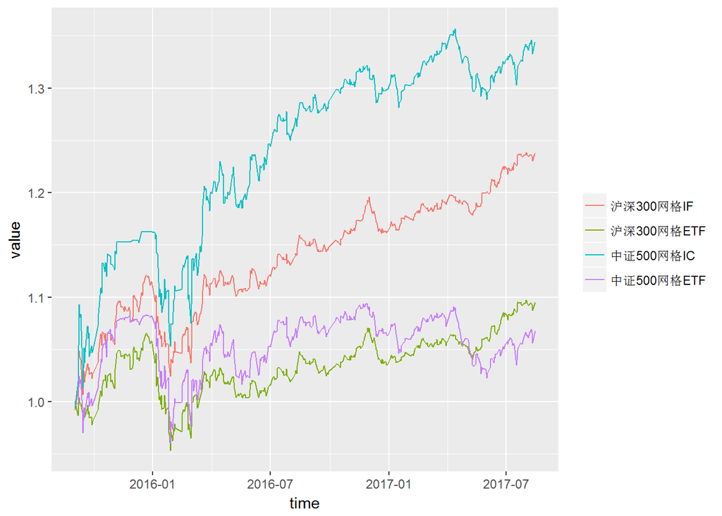

网格交易的收益统计如下表：

|  | 沪深300指数 | 沪深300网格IF | 沪深300网格ETF | 中证500指数 | 中证500网格IC | 中证500网格ETF |
| --- | --- | --- | --- | --- | --- | --- |
| 2015-09-02 ~ 2015-12-31 | 11.0% | 11.1% | 5.6% | 23.5% | 16.2% | 8.1% |
| 2016-01-04 ~ 2016-12-30 | -11.3% | 4.7% | -1.8% | -17.8% | 11.8% | -1.6% |
| 2017-01-03 ~ 2017-08-15 | 12.0% | 6.4% | 5.6% | 0.8% | 3.4% | 0.4% |
| 累计收益率 | 10.2% | 23.8% | 9.5% | 2.4% | 34.4% | 6.8% |
| 年化收益率 | 5.1% | 11.5% | 4.7% | 1.2% | 16.3% | 3.4% |
| 年化波动率 | 20.2% | 8.4% | 8.2% | 27.4% | 12.4% | 10.8% |
| 年化Sharpe值 | 25.3% | 137.3% | 57.7% | 4.4% | 131.1% | 31.6% |
| 最大回撤 | 26.4% | 8.6% | 10.5% | 33.5% | 9.4% | 11.4% |

## E、选股

### (e1)大小市值100

作为多因子选股的第一部分，有必要从市值因子说起。 下面利用总市值因子，在中证全指的成分股内，选出市值最大和最小的100只股票，这里剔除了ST、新上市、停牌和涨停的股票，等权配置，每月换仓一次，交易成本千分之三。观察历年来大、小市值组净值表现如下图。

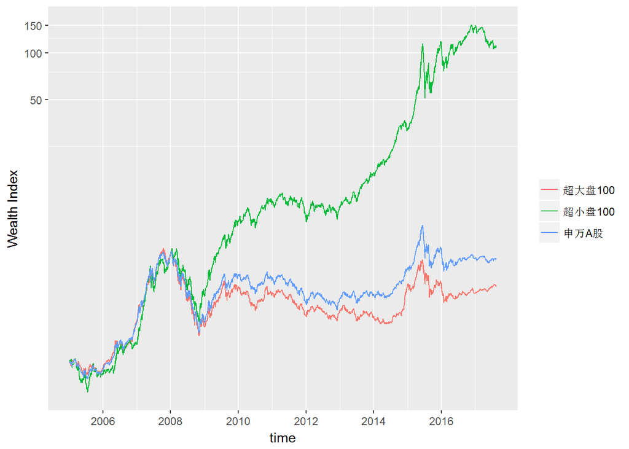

大小市值100的收益统计如下表：

|  | 超大盘100 | 超小盘100 | 申万A股 |
| --- | --- | --- | --- |
| 2005-01-05 ~ 2005-12-30 | -8.0% | -15.5% | -10.1% |
| 2006-01-04 ~ 2006-12-29 | 104.5% | 56.5% | 103.9% |
| 2007-01-04 ~ 2007-12-28 | 163.5% | 270.9% | 167.2% |
| 2008-01-02 ~ 2008-12-31 | -65.6% | -45.1% | -62.8% |
| 2009-01-05 ~ 2009-12-31 | 82.8% | 206.5% | 105.6% |
| 2010-01-04 ~ 2010-12-31 | -9.9% | 32.0% | -6.8% |
| 2011-01-04 ~ 2011-12-30 | -27.2% | -19.5% | -28.6% |
| 2012-01-04 ~ 2012-12-31 | 7.7% | 15.8% | 4.9% |
| 2013-01-04 ~ 2013-12-31 | -9.2% | 65.4% | 6.3% |
| 2014-01-02 ~ 2014-12-31 | 55.5% | 89.8% | 44.9% |
| 2015-01-05 ~ 2015-12-31 | 4.5% | 266.7% | 35.3% |
| 2016-01-04 ~ 2016-12-30 | -13.5% | 24.7% | -13.6% |
| 2017-01-03 ~ 2017-08-15 | 12.0% | -23.4% | 0.4% |
| 累计收益率 | 215.0% | 11072.6% | 372.2% |
| 年化收益率 | 9.5% | 45.3% | 13.1% |
| 年化波动率 | 28.8% | 35.5% | 28.3% |
| 年化Sharpe值 | 33.1% | 127.5% | 46.2% |
| 最大回撤 | 72.9% | 66.4% | 70.5% |

### (e2)银行股轮动

银行股轮动是参考集思录的热门贴银行股评级而来的，数据的提取和参数的设置和原贴有一定的差别，所以轮动的效果也会不太一样，不过回测的效果还不错，从现在开始跟踪。2013年以来银行股轮动的结果如下图：

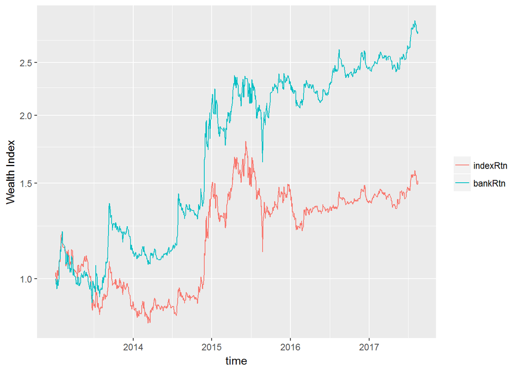

银行股轮动的收益统计如下表：

|  | 申万银行 | 银行股轮动 |
| --- | --- | --- |
| 2013-01-04 ~ 2013-12-31 | -9.2% | 12.5% |
| 2014-01-02 ~ 2014-12-31 | 63.2% | 87.6% |
| 2015-01-05 ~ 2015-12-31 | -1.4% | 9.4% |
| 2016-01-04 ~ 2016-12-30 | -4.9% | 6.2% |
| 2017-01-04 ~ 2017-08-15 | 8.9% | 16.2% |
| 累计收益率 | 51.3% | 185.1% |
| 年化收益率 | 9.4% | 25.5% |
| 年化波动率 | 27.3% | 29.2% |
| 年化Sharpe值 | 34.3% | 87.1% |
| 最大回撤 | 37.4% | 30.8% |

银行股轮动的最新得分如下表：

| 日期 | 代码 | 简称 | PB | ROE | 翻倍期 | 持仓 |
| --- | --- | --- | --- | --- | --- | --- |
| 2017-08-15 | EQ601818 | 光大银行 | 0.76 | 0.12 | 3.8 |  |
| 2017-08-15 | EQ600015 | 华夏银行 | 0.79 | 0.12 | 3.9 |  |
| 2017-08-15 | EQ601328 | 交通银行 | 0.74 | 0.10 | 4.0 | hold |
| 2017-08-15 | EQ600016 | 民生银行 | 0.88 | 0.14 | 4.4 |  |
| 2017-08-15 | EQ601288 | 农业银行 | 0.90 | 0.14 | 4.6 |  |
| 2017-08-15 | EQ601988 | 中国银行 | 0.84 | 0.11 | 4.9 |  |
| 2017-08-15 | EQ601998 | 中信银行 | 0.83 | 0.11 | 4.9 |  |
| 2017-08-15 | EQ600000 | 浦发银行 | 0.96 | 0.14 | 5.0 |  |
| 2017-08-15 | EQ601166 | 兴业银行 | 1.02 | 0.14 | 5.4 |  |
| 2017-08-15 | EQ000001 | 平安银行 | 0.88 | 0.11 | 5.5 |  |
| 2017-08-15 | EQ601398 | 工商银行 | 1.02 | 0.14 | 5.5 |  |
| 2017-08-15 | EQ601169 | 北京银行 | 0.95 | 0.12 | 5.6 |  |
| 2017-08-15 | EQ601939 | 建设银行 | 1.08 | 0.14 | 5.8 |  |
| 2017-08-15 | EQ601009 | 南京银行 | 1.06 | 0.13 | 6.0 |  |
| 2017-08-15 | EQ600919 | 江苏银行 | 1.22 | 0.13 | 7.4 |  |
| 2017-08-15 | EQ601997 | 贵阳银行 | 1.63 | 0.17 | 7.4 |  |
| 2017-08-15 | EQ002142 | 宁波银行 | 1.55 | 0.16 | 7.7 |  |
| 2017-08-15 | EQ601229 | 上海银行 | 1.25 | 0.12 | 8.0 |  |
| 2017-08-15 | EQ600036 | 招商银行 | 1.60 | 0.15 | 8.2 |  |
| 2017-08-15 | EQ600926 | 杭州银行 | 1.38 | 0.10 | 10.3 |  |
| 2017-08-15 | EQ601128 | 常熟银行 | 2.41 | 0.11 | 15.1 |  |
| 2017-08-15 | EQ600908 | 无锡银行 | 2.41 | 0.10 | 16.1 |  |
| 2017-08-15 | EQ603323 | 吴江银行 | 2.09 | 0.08 | 17.7 |  |
| 2017-08-15 | EQ002807 | 江阴银行 | 2.38 | 0.09 | 18.6 |  |
| 2017-08-15 | EQ002839 | 张家港行 | 3.45 | 0.09 | 23.4 |  |